# HBV

# HBV

# What is it?

### The model

The HBV model is among the classical, conceptual hydrological precipitation – runoff models. It was developed far back in the seventies (Bergstrøm, 1976), designed for a reasonable demand of computer capacities, as was available at that time. The original model has undergone numerous revisions and improvements, and today there are several implementations of HBV available. In the present application, the “Nordic” HBV model (Killingveit and Sælthun, 1995; Sælthun, 1996) is used. For a detailed review of the model, please refer to these publications. A brief introduction to the model is given below. See figure 1 for an illustration.

The model can be classified as a semi-distributed conceptual model. It uses the subbasin as the primary hydrological unit, and within this, an area-elevation distribution and a crude classification of land use is implemented. All processes contribute directly to runoff at the outlet without internal routing between elevation zones or along the river reaches. The model consists of subroutines for - snow accumulation and melt - soil moisture accounting - dynamic part: runoff generation

*The snow routine* controls snow accumulation and melt, and works separately for each elevation and vegetation zone. Additional snow over a given accumulated storage is distributed according to a lognormal pattern, specified by two parameters. The division of rain from snow and melting from non-melting is controlled by threshold temperatures. Snow melt is estimated by a simple degree-day expression. The water holding capacity of snow has to be exceeded before any runoff is generated. During cold periods, the content of free water in the snow is reduced under the operation of a refreezing coefficient. All the subdivisions of the snow distribution in an altitude zone is treated individually, ensuring a fragmented snow pattern by the end of the winter season. In the present model version, snow on glaciers accumulates and melts at the same rate as snow on non-glacierized areas in the same altitude level.

An essential part of the HBV model is the *soil moisture accounting routine*. Rain and meltwater from snow and glaciers is separated into input to the soil moisture zone and percolation to the dynamical part of the model. The share of the input retained in the soil moisture zone is controlled by the water content in this zone. In addition, water can be drawn up to the zone from the ground water zones. Actual evapotranspiration is calculated based on the water content in this zone. Once captured in the zone, water is only removed by evapotranspiration.

Runoff is generated in the *upper and lower zones* of the model. The excess percolation water from the soil moisture zone is transformed to runoff for the catchment as a whole, by piecewise linear reservoirs with three outlets. The upper level represents the rapid storm flow, whereas the lower one provides for the long-term base flow of the basin. The momentary response is integrated over the time step. As long as there is water in the upper zone, a constant deep percolation feeds the lower zone.

As a conceptual model, the HBV model has only a minor physical resemblance to the natural processes in the associated catchment. Some physiographical parameters, like catchment area, hypsographic curve etc. can be quantified from GIS data, but the majority of the parameters must be calibrated, i.e. they are adjusted so that model simulated runoff, given a defined input data set, is as similar as possible to the observed runoff. The HBV model is calibrated for the 145 flood forecasting model catchments.

Input data to the model are precipitation and temperature from the seNorge data set. Data for each altitude zone are read separately from the grid, and applied directly for each zone, without any altitude correction.

*Figure 1: the structure of the HBV model to the right. An illustration of input data for 10 altitude zones is shown to the left.*

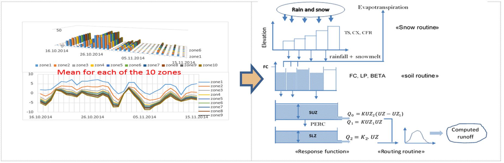

### Post processing

#### HBV_UM: the NVE uncertainty model

At NVE, a stochastic method for quantifying uncertainty in runoff forecasts is developed and incorporated as a part of the flood forecasting system. Two major sources of uncertainty are taken into account; the uncertainty due to error in the forecasted temperature and precipitation (Follestad and Høst, 1998), and the uncertainty due to error inherent in the rainfall runoff model, here the HBV model (Langsrud et al., 1998). A third module quantifies the composite uncertainty in runoff forecasts (Langsrud et al., 1999). The method has been validated with good results (Langsholt and Ruan, 2015).

The objective is to quantify the uncertainty in the runoff forecast for day t, made j days earlier, Q<sub>FOR</sub><sup>(j)</sup>(t), based on forecasted precipitation and temperature. At NVE, forecasts are made with a lead time up to nine days, i.e. j = 1, …, 9. This means that we will identify the distribution of errors Q<sub>OBS</sub>(t) - Q<sub>FOR</sub><sup>(j)</sup>(t), or, alternatively, the distribution of Q<sub>OBS</sub>(t), the observed stream flow at day t, conditioned on information available j days earlier, when the forecast Q<sub>FOR</sub><sup>(j)</sup>(t) was made. The conditional distribution is thus conditioned on observations of precipitation, temperature and stream flow up to day t-j and forecasts of precipitation and temperature. The error is decomposed into two parts:

Q<sub>OBS</sub>(t) - Q<sub>FOR</sub><sup>(j)</sup>(t) = (Q<sub>OBS</sub>(t) - Q<sub>SIM</sub>(t)) + (Q<sub>SIM</sub>(t) - Q<sub>FOR</sub><sup>(j)</sup>(t)) .

The first term on the right hand side represents the inherent errors of the HBV model, the difference between observed stream flow and stream flow simulated with observed precipitation and temperature. It can be noticed that observation errors of precipitation and temperature will be included in this error component along with errors due to lack of representativity of the meteorological observations. The second term is the error due to the uncertainty in the meteorological forecasts of temperature and precipitation, i.e. the difference in model calculated runoff with observed and forecasted meteorology.

The uncertainty model is catchment specific and needs to be calibrated for each catchment separately. The method is implemented for routinely simulations of uncertainty and probabilities associated with HBV model forecasts. Statistical distributions for temperature and precipitation in the forecast period are developed on the basis of historical forecasts and observation data, and include parameters that are dependent on present and forecasted meteorological conditions. The HBV model error is modelled as a first order autoregressive process, i.e. the error of day t, depends on the error the previous day.

An algorithm runs Monte Carlo simulations of the HBV model on precipitation and temperature realisations drawn from the estimated distributions for the forecast period. Due to time consumption, only 100 MC runs are applied operationally per catchment. The resulting empirical distribution of the composite error forms the basis for the probability calculations. In the app, the median (HBV.UM.korr) and the confidence interval boundaries (Lo90, Lo50, Hi50 and Hi90), are estimates based on the empirical distribution from the NVE uncertainty model. Probability of exceeding different flood thresholds is another estimate that is widely used by the flood forecasters, and which is suitable as a classifying measure in the application map.

Unfortunately, there are two problems that prevent optimal adaptation of the uncertainty model to current versions of the model and the input weather data. First, there are frequent updates in either of the variables, which makes it too time consuming to keep the calibration up with new implementations. Second, it is difficult to obtain long time series of weather forecast data, homogeneous with the operational versions, to make a proper calibration. For these reasons, the uncertainty model is, at present, not properly updated, and it will be replaced with a weather forecast ensemble based method when this is established.

#### Sensitivity to precipitation

As a simple measure of how sensitive the runoff forecast is to variations in the precipitation, the HBV model is run with three different precipitation forecasts: the operational forecast and the operational reduced and increased by 50 percent, respectively. The effect of this juggling of the input data on the runoff forecast is shown as P.m50 and P.p50 in the app.

The associated bias corrected runoff forecast, HBV.P.korr, does not take precipitation uncertainty into consideration, and refers to the median in an empirical ensemble, similar to the one described in the above section, but based on temperature uncertainty, solely. Temperature uncertainty obviously plays a role only when snow accumulation and -melt is in question.

### References

Bergström, S. 1976. Development and application of a conceptual runoff model for Scandinavian catchments. SMHI Report RH07.

Follestad, T. and Høst, G., 1998. A statistical model for the uncertainty of meteorological forecasts with application to the Knappom and Røykenes catchments. HYDRA note no 12, Oslo, Norway

Killingveit, Å. and N. R. Sælthun. 1995. Hydrological models. In Hydropower Development 7: Hydrology. Trondheim: Norwegian Institute of Technology, pp. 99-128.

Langsholt, E. and G. Ruan. 2015. Evaluering av flomvarslingas usikkerhetsmodell. NVE Rapport 47-2015.

Langsrud, Ø., Frigessi, A. and Høst, G., 1998. Pure model error for the HBV model. HYDRA note no 4., Oslo, Norway

Langsrud, Ø., Høst, G., Follestad, T. and Frigessi, A., 1999. Quantifying uncertainty in HBV runoff forecasts by stochastic simulations. HYDRA note no 2., Oslo, Norway

Lussana, C., Tveito, O. E. and Uboldi, F. 2016. seNorge v2.0, Temperature. An observational gridded dataset of temperature for Norway. METreport 14/2016

Sælthun, N.S. 1996. The Nordic HBV Model. NVE Publication no. 07, 26 pp.